# Practical Machine Learning/ Prediction Assignment

## Background

Using devices such as Jawbone Up, Nike FuelBand, and Fitbit it is now possible to collect a large amount of data about personal activity relatively inexpensively. These type of devices are part of the quantified self movement Â- a group of enthusiasts who take measurements about themselves regularly to improve their health, to find patterns in their behavior, or because they are tech geeks.

One thing that people regularly do is quantify how much of a particular activity they do, but they rarely quantify how well they do it. In this data set, the participants were asked to perform barbell lifts correctly and incorrectly in 5 different ways. More information is available from the website here: http://groupware.les.inf.puc-rio.br/har (see the section on the Weight Lifting Exercise Dataset).

In this project, the goal will be to use data from accelerometers on the belt, forearm, arm, and dumbell of 6 participants toto predict the manner in which praticipants did the exercise.

The dependent variable or response is the “classe” variable in the training set.

## Data

Download and load the data.

```r
#download.file("https://d396qusza40orc.cloudfront.net/predmachlearn/pml-training.csv", destfile = "./pml-training.csv")
#download.file("http://d396qusza40orc.cloudfront.net/predmachlearn/pml-testing.csv", destfile = "./pml-testing.csv")

setwd("C:/Users/Karishma/Desktop/coursera")

trainingOrg = read.csv("pml-training.csv", na.strings=c("", "NA", "NULL"))
# data.train =  read.csv("https://d396qusza40orc.cloudfront.net/predmachlearn/pml-training.csv", na.strings=c("", "NA", "NULL"))

testingOrg = read.csv("pml-testing.csv", na.strings=c("", "NA", "NULL"))
dim(trainingOrg)
```

```
## [1] 19622   160
```

```r
dim(testingOrg)
```

```
## [1]  20 160
```

## Pre-screening the data

There are several approaches for reducing the number of predictors.

Remove variables that we believe have too many NA values.

```r
training.dena <- trainingOrg[ , colSums(is.na(trainingOrg)) == 0]
#head(training1)
#training3 <- training.decor[ rowSums(is.na(training.decor)) == 0, ]
dim(training.dena)
```

```
## [1] 19622    60
```

Remove unrelevant variables There are some unrelevant variables that can be removed as they are unlikely to be related to dependent variable.

```r
remove = c('X', 'user_name', 'raw_timestamp_part_1', 'raw_timestamp_part_2', 'cvtd_timestamp', 'new_window', 'num_window')
training.dere <- training.dena[, -which(names(training.dena) %in% remove)]
dim(training.dere)
```

```
## [1] 19622    53
```

Check the variables that have extremely low variance (this method is useful nearZeroVar()

```r
library(caret)
# only numeric variabls can be evaluated in this way.

zeroVar= nearZeroVar(training.dere[sapply(training.dere, is.numeric)], saveMetrics = TRUE)
training.nonzerovar = training.dere[,zeroVar[, 'nzv']==0]
dim(training.nonzerovar)
```

```
## [1] 19622    53
```

Remove highly correlated variables 90% (using for example findCorrelation()

```r
# only numeric variabls can be evaluated in this way.
corrMatrix <- cor(na.omit(training.nonzerovar[sapply(training.nonzerovar, is.numeric)]))
dim(corrMatrix)
```

```
## [1] 52 52
```

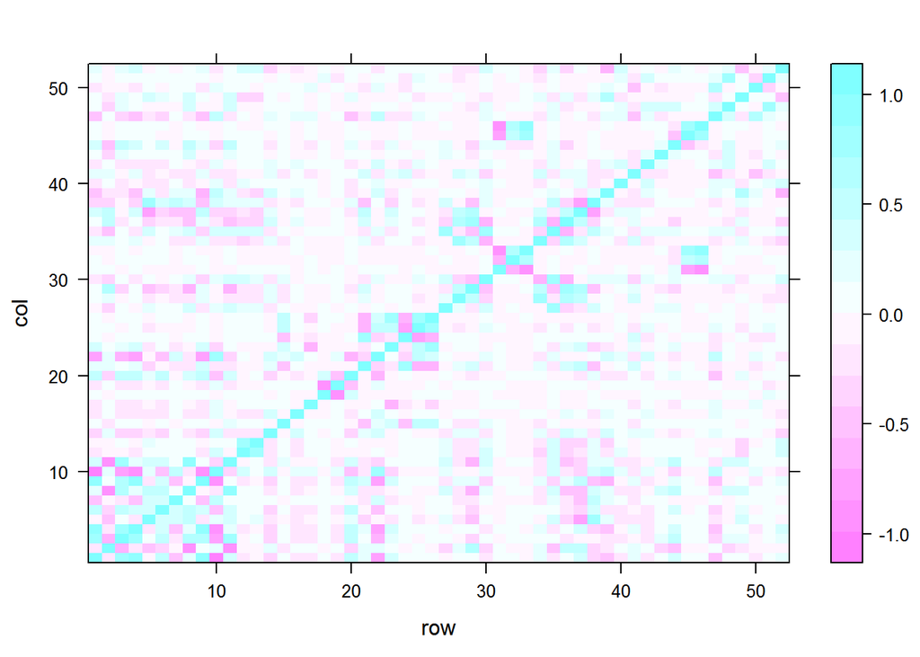

```r
# there are 52 variables.
corrDF <- expand.grid(row = 1:52, col = 1:52)
corrDF$correlation <- as.vector(corrMatrix)
levelplot(correlation ~ row+ col, corrDF)
```

We are going to remove those variable which have high correlation.

```r
removecor = findCorrelation(corrMatrix, cutoff = .90, verbose = TRUE)
```

```
## Compare row 10  and column  1 with corr  0.992
##   Means:  0.27 vs 0.168 so flagging column 10
## Compare row 1  and column  9 with corr  0.925
##   Means:  0.25 vs 0.164 so flagging column 1
## Compare row 9  and column  4 with corr  0.928
##   Means:  0.233 vs 0.161 so flagging column 9
## Compare row 8  and column  2 with corr  0.966
##   Means:  0.245 vs 0.157 so flagging column 8
## Compare row 19  and column  18 with corr  0.918
##   Means:  0.091 vs 0.158 so flagging column 18
## Compare row 46  and column  31 with corr  0.914
##   Means:  0.101 vs 0.161 so flagging column 31
## Compare row 46  and column  33 with corr  0.933
##   Means:  0.083 vs 0.164 so flagging column 33
## All correlations <= 0.9
```

```r
training.decor = training.nonzerovar[,-removecor]
dim(training.decor)
```

```
## [1] 19622    46
```

## Split data to training and testing for cross validation.

```r
inTrain <- createDataPartition(y=training.decor$classe, p=0.7, list=FALSE)
training <- training.decor[inTrain,]; testing <- training.decor[-inTrain,]
dim(training);dim(testing)
```

```
## [1] 13737    46
```

```
## [1] 5885   46
```

We got 13737 samples and 46 variables for training, 5885 samples and 46 variables for testing.

## Analysis

Now we fit a tree to these data, and summarize and plot it. First, we use the ‘tree’ package. It is much faster than ‘caret’ package.

```r
library(tree)
set.seed(12345)
tree.training=tree(classe~.,data=training)
summary(tree.training)
```

```
##
## Classification tree:
## tree(formula = classe ~ ., data = training)
## Variables actually used in tree construction:
##  [1] "pitch_forearm"     "magnet_belt_y"     "accel_forearm_z"
##  [4] "magnet_dumbbell_y" "roll_forearm"      "magnet_dumbbell_z"
##  [7] "accel_dumbbell_y"  "pitch_belt"        "yaw_belt"
## [10] "accel_dumbbell_z"  "accel_forearm_x"   "magnet_arm_x"
## [13] "gyros_belt_z"
## Number of terminal nodes:  20
## Residual mean deviance:  1.665 = 22840 / 13720
## Misclassification error rate: 0.3279 = 4505 / 13737
```

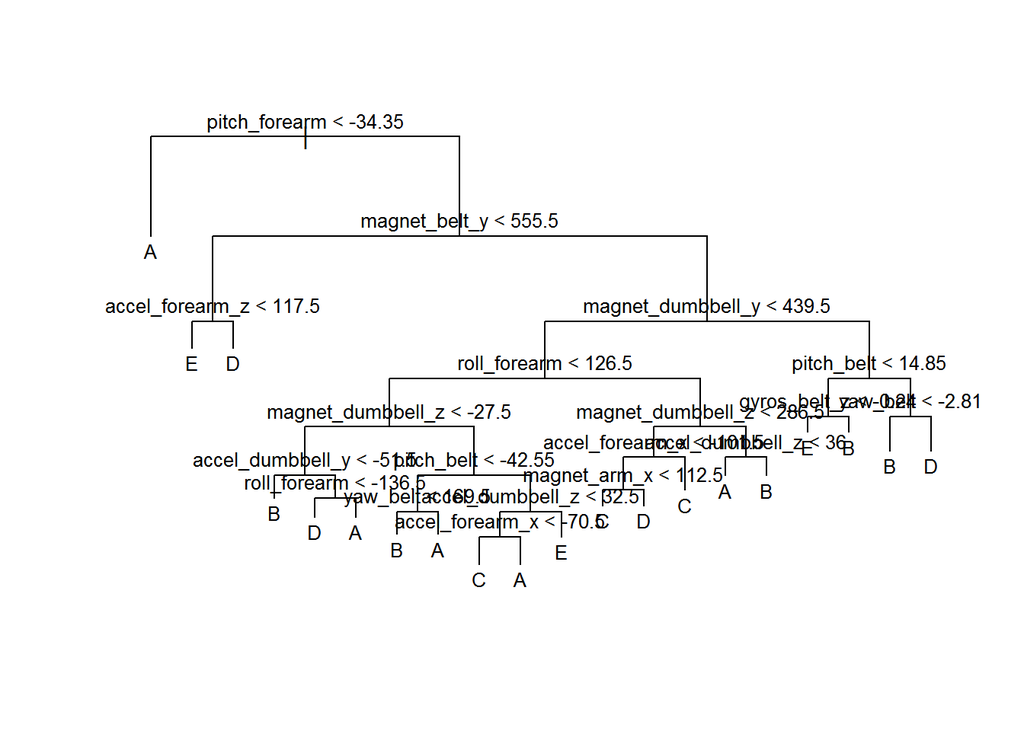

```r
plot(tree.training)
text(tree.training,pretty=0, cex =.8)
```

This is a bushy tree, and we are going to prune it.

## Rpart form Caret, very slow.

```r
library(caret)
modFit <- train(classe ~ .,method="rpart",data=training)
print(modFit$finalModel)
```

```
## n= 13737
##
## node), split, n, loss, yval, (yprob)
##       * denotes terminal node
##
##  1) root 13737 9831 A (0.28 0.19 0.17 0.16 0.18)
##    2) pitch_forearm< -33.95 1104    9 A (0.99 0.0082 0 0 0) *
##    3) pitch_forearm>=-33.95 12633 9822 A (0.22 0.21 0.19 0.18 0.2)
##      6) magnet_belt_y>=555.5 11623 8814 A (0.24 0.23 0.21 0.18 0.15)
##       12) magnet_dumbbell_y< 439.5 9710 6958 A (0.28 0.18 0.24 0.17 0.13)
##         24) roll_forearm< 123.5 6146 3676 A (0.4 0.18 0.18 0.14 0.095) *
##         25) roll_forearm>=123.5 3564 2359 C (0.079 0.19 0.34 0.22 0.18)
##           50) accel_forearm_x>=-104.5 2501 1532 C (0.086 0.22 0.39 0.086 0.22) *
##           51) accel_forearm_x< -104.5 1063  496 D (0.062 0.095 0.22 0.53 0.087) *
##       13) magnet_dumbbell_y>=439.5 1913 1022 B (0.03 0.47 0.042 0.21 0.25) *
##      7) magnet_belt_y< 555.5 1010  187 E (0.002 0.00099 0.00099 0.18 0.81) *
```

## Prettier plots

```r
library(rattle)
```

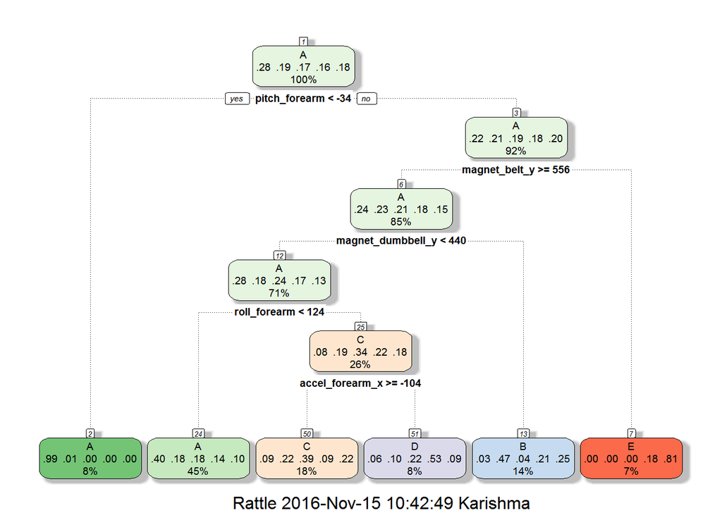

```r
fancyRpartPlot(modFit$finalModel)
```

##Cross Validation

We are going to check the performance of the tree on the testing data by cross validation.

```r
tree.pred=predict(tree.training,testing,type="class")
predMatrix = with(testing,table(tree.pred,classe))
sum(diag(predMatrix))/sum(as.vector(predMatrix)) # error rate
```

```
## [1] 0.673237
```

```r
tree.pred=predict(modFit,testing)
predMatrix = with(testing,table(tree.pred,classe))
sum(diag(predMatrix))/sum(as.vector(predMatrix)) # error rate
```

```
## [1] 0.4983857
```

The 0.50 from ‘caret’ package is much lower than the result from ‘tree’ package.

## Pruning tree

This tree was grown to full depth, and might be too variable. We now use Cross Validation to prune it.

```r
cv.training=cv.tree(tree.training,FUN=prune.misclass)
cv.training
```

```
## $size
##  [1] 20 19 18 17 16 15 14 13 10  7  5  1
##
## $dev
##  [1] 4606 4694 4805 4950 5032 5289 5319 6144 6144 6750 7276 9831
##
## $k
##  [1]     -Inf  73.0000 104.0000 127.0000 134.0000 152.0000 165.0000
##  [8] 197.0000 198.3333 227.0000 265.5000 641.7500
##
## $method
## [1] "misclass"
##
## attr(,"class")
## [1] "prune"         "tree.sequence"
```

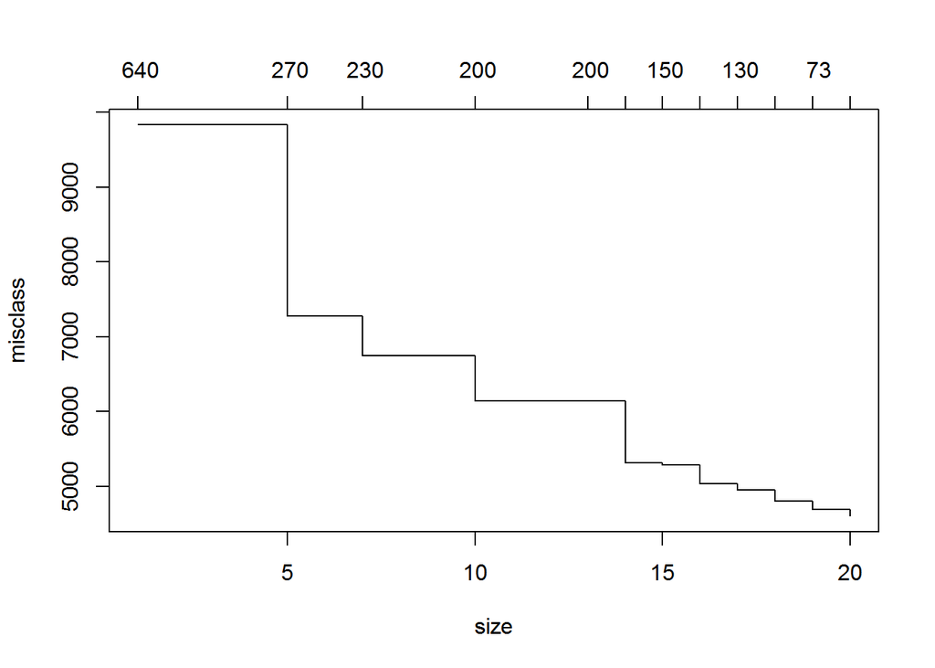

```r
plot(cv.training)
```

```r
prune.training=prune.misclass(tree.training,best=18)
```

Now lets evaluate this pruned tree on the test data.

```r
tree.pred=predict(prune.training,testing,type="class")
predMatrix = with(testing,table(tree.pred,classe))
sum(diag(predMatrix))/sum(as.vector(predMatrix))
```

```
## [1] 0.6579439
```

## Random Forests

Random forests build lots of bushy trees, and then average them to reduce the variance.

```r
require(randomForest)
set.seed(12345)
```

Lets fit a random forest and see how well it performs.

```r
rf.training=randomForest(classe~.,data=training,ntree=100, importance=TRUE)
rf.training
```

```
##
## Call:
##  randomForest(formula = classe ~ ., data = training, ntree = 100,      importance = TRUE)
##                Type of random forest: classification
##                      Number of trees: 100
## No. of variables tried at each split: 6
##
##         OOB estimate of  error rate: 0.68%
## Confusion matrix:
##      A    B    C    D    E  class.error
## A 3904    2    0    0    0 0.0005120328
## B   14 2628   14    0    2 0.0112866817
## C    0   24 2370    2    0 0.0108514190
## D    0    0   26 2226    0 0.0115452931
## E    0    0    3    7 2515 0.0039603960
```

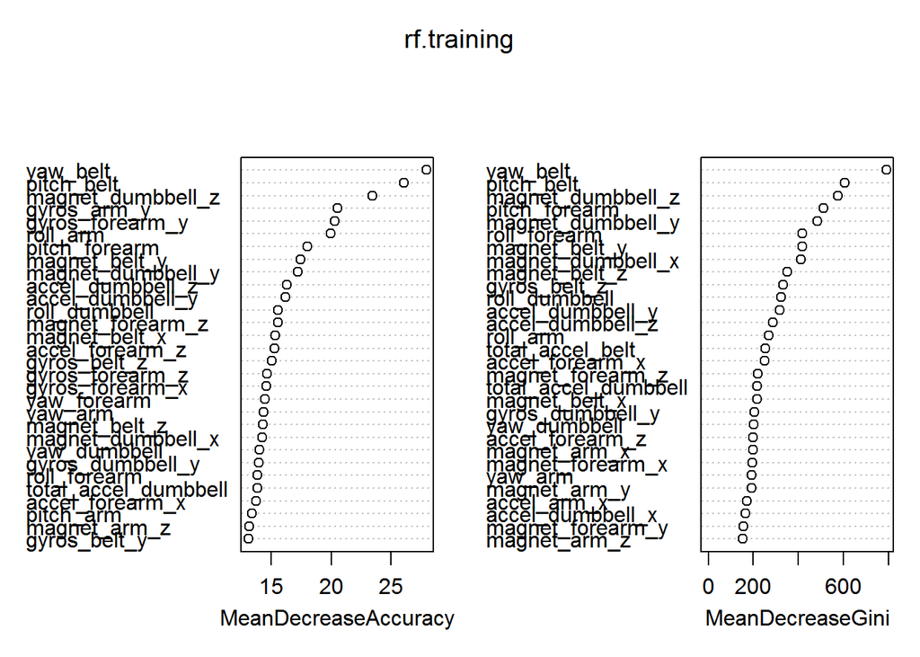

```r
#plot(rf.training, log="y")
varImpPlot(rf.training)
```

Now lets evaluate this tree on the test data.

```r
tree.pred=predict(rf.training,testing,type="class")
predMatrix = with(testing,table(tree.pred,classe))
sum(diag(predMatrix))/sum(as.vector(predMatrix)) # error rate
```

```
## [1] 0.9947324
```

0.99 means we got a very accurate estimate. ##Conclusion

Now we can predict the testing data from the website.

```r
answers <- predict(rf.training, testingOrg)
answers
```

```
##  1  2  3  4  5  6  7  8  9 10 11 12 13 14 15 16 17 18 19 20
##  B  A  B  A  A  E  D  B  A  A  B  C  B  A  E  E  A  B  B  B
## Levels: A B C D E
```